# Udacity Data Analyst Nanodegree Program

### Data Visualization: Communicate Data Findings

with Ford GoBike System Data

author: andrew nachtigal

## Investigation Overview

### Data Visualization Project Data Analysis Goals

- Transportation is a important issue for many city planners. Providing alternative means of commuting and transportation is increasingly important to mitigate vehicle congestion and CO2 emissions.
- Understanding residents' demand and use patterns for bicycles allows city administrators to effectively plan and manage bike share systems. The following analysis aims to provide an overview of year 2018 GoBike system, identify temporal ridership patterns, and to visualize geographic bike station use patterns.

## Investigation Overview (cont'd)

### Overview of GoBike Bike Share System

- Describe bike share system
- Describe bike share users
- Describe temporal ridership patterns:
  - Monthly use by start-time
  - Day-of-week use by start-time
  - Hourly use by start-time
- Visualize geographic station demand

### Dataset Overview

The dataset used in this project is Ford Gobike system data for 2018 which includes information about individual rides made in a bike-sharing system covering the greater San Francisco Bay area. Bike share provides station-to-station trips around San Francsico to facilitate greater use of bicycles as a means of commute and to integrate biking into residents' daily life.

## Age Distribution of GoBike Riders

- There appear to be many bike riders over the age of 100 in San Francisco!
- These ages are clearly incorrect but it is more important to leave this data as-is in order to know the total number of riders using the system. The age of every rider is less important for most planning purposes.
- Many GoBike users prefered to keep their age anonymous or provided an incorrect age. Considering the increased awareness around data privacy issues, this is not surprising.

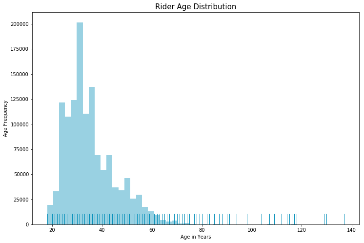

```python
from IPython.display import Image
Image(filename='plots/rider-age-dist.png')
```

## Hourly Ride Start Pattern

Plotting ride starts for every hour of the day, we can see increased demand around daily work commute times.

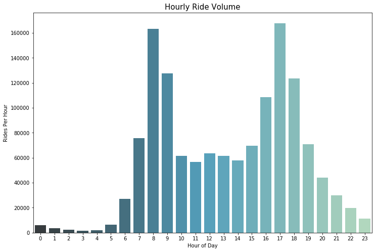

```python
from IPython.display import Image
Image(filename='plots/hourly-ride-volume.png')
```

## Monthly Bikeshare Use by Gender

This graph reflects that men are the major system users. It might be a good question for city planners to ask why more women aren't using the system and attempt to address this issue.

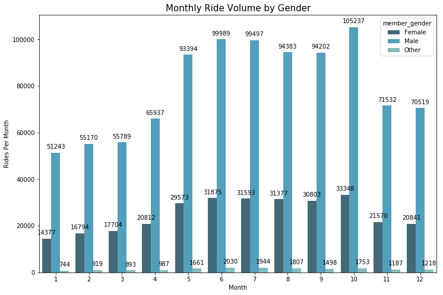

```python
from IPython.display import Image
Image(filename='plots/monthly-gender-volume.png')
```

## Monthly Bikeshare Use by User Type

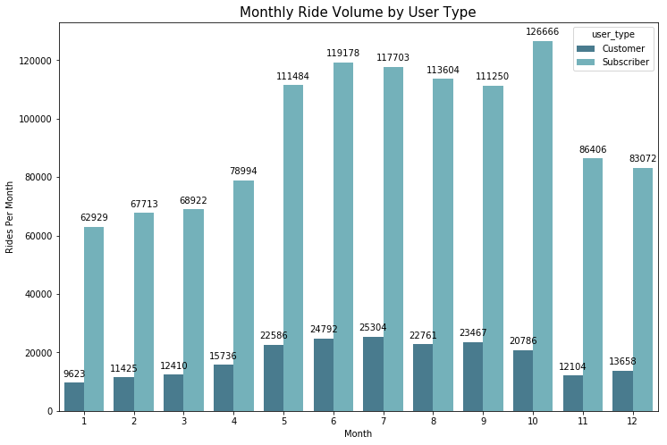

```python
from IPython.display import Image
Image(filename='plots/monhtly-user-type-volume.png')
```

## Geographical Station Demand Plot

- Marker color and size depend on total station demand
- Smaller and blue markers indicate less demand
- larger and red markers indicate greater demand

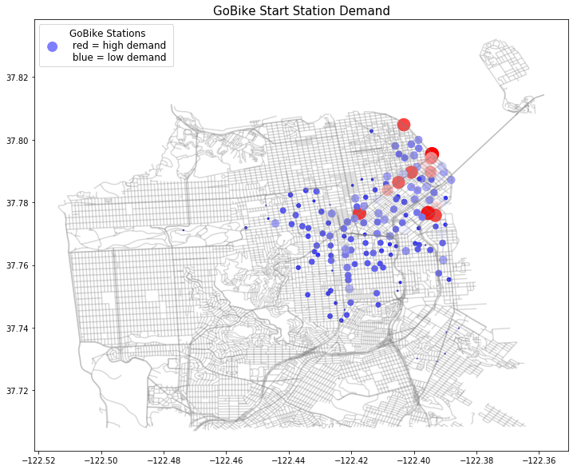

```python
from IPython.display import Image
Image(filename='plots/start_station-intensity.png')
```